# image localisation flowers

based on https://blogs.rstudio.com/tensorflow/posts/2018-11-05-naming-locating-objects/

```r
#load packages
library(keras)
library(rjson)
library(magick) #may need terminal command: sudo apt-get install libmagick++-dev
library(purrr)
library(tibble)
library(tidyr)
library(dplyr)
library(ggplot2)
library(stringr)
library(repurrrsive)
library(listviewer)
library(magrittr)
```

```r
#define image directories
img_dir <- "~/compvis_flowers_1/data/quadrats/images_voc"
annot_coco_file <- "../data/quadrats/export-coco-2019-03-05T14_31_52.619981.json"
annot_csv_file <- "../data/quadrats/export-2019-03-05T17_20_33.839Z.csv"
```

```r
#Image attributes
#image annotations
annotations <- fromJSON(file = annot_coco_file)
#str(annotations, max.level = 1)
imageinfo <- annotations$images %>% {
  tibble(
    id = map_chr(., "id"),
    file_name = map_chr(., "file_name"),
    image_height = map_dbl(., "height"),
    image_width = map_dbl(., "width")
  )
}
imageinfo
```

| id | file_name | image_height | image_width |
| --- | --- | --- | --- |
| cjsga03745kcx0728mqnrd5kg | https://storage.googleapis.com/labelbox-193903.appspot.com/cjp8dfyxkyqd60980fbwe4pao%2F3187fce2-8f3b-d081-8fd5-0fca1d0632e6-117-pic_s08_2017_ne_q01-alsiclov_crimclov_whitclov_lucerne_birdtref_blacmedi… | 796 | 1418 |
| cjsg9wisi5l6e0812exfctseb | https://storage.googleapis.com/labelbox-193903.appspot.com/cjp8dfyxkyqd60980fbwe4pao%2F66b6f1a4-d184-98eb-77a2-32d9bef6ba41-116-pic_s30_2018_ne_q06-alsiclov_redclov_birdtref_sainfoin.jpg | 4032 | 3024 |
| cjsg9vyjp5k1n08121wub5482 | https://storage.googleapis.com/labelbox-193903.appspot.com/cjp8dfyxkyqd60980fbwe4pao%2Fb9aeca2c-f12e-e172-21a9-e91a19694a76-115-pic_s05_2017_ne_q04-alsiclov_crimclov_redclov_sainfoin_birdtref.png | 835 | 1114 |
| cjsg9owb34wco0728si10652q | https://storage.googleapis.com/labelbox-193903.appspot.com/cjp8dfyxkyqd60980fbwe4pao%2F51aaf1f5-058b-bc2e-32c3-1de26fc85088-114-7-pic_s04_2017_ne_q10-alsiclov_redclov_sainfoin_lucerne_birdtref_blacmed… | 453 | 453 |
| cjsg9m00w4z4k0812gd8mneif | https://storage.googleapis.com/labelbox-193903.appspot.com/cjp8dfyxkyqd60980fbwe4pao%2Faefbd0d7-36f5-5cc2-832e-ab3c0c520e02-113-pic_s05_2017_ne_q02-alsiclov_crimclov_redclov_lucerne_birdtref.png | 825 | 1099 |
| cjsg9i78b4qwk08129sjojw1d | https://storage.googleapis.com/labelbox-193903.appspot.com/cjp8dfyxkyqd60980fbwe4pao%2Fd0d55c29-5445-d43f-c8bc-5caba73729f4-112-pic_s23_2017_ne_q03-phacelia_tuftvetc.png | 826 | 1102 |
| cjsg9h32s4g9n072819yprfub | https://storage.googleapis.com/labelbox-193903.appspot.com/cjp8dfyxkyqd60980fbwe4pao%2Ff97b794a-6b42-a2da-2b81-96c91f358443-109-pic_s27_2017_ne_q08-alsiclov_redclov_sainfoin_lucerne_birdtref_phacelia.… | 395 | 527 |
| cjsg9fgbr4dah0728izsgjx3e | https://storage.googleapis.com/labelbox-193903.appspot.com/cjp8dfyxkyqd60980fbwe4pao%2F13818523-90e9-565e-444e-aceb26d89a43-108-pic_s23_2017_ne_q09-NA.png | 818 | 1091 |
| cjsg9eq7o4kol0812ewvj0ltx | https://storage.googleapis.com/labelbox-193903.appspot.com/cjp8dfyxkyqd60980fbwe4pao%2Fce14ff62-86fe-0073-0466-9f6ad3f8956d-107-pic_s23_2017_ne_q02-NA.png | 833 | 1110 |
| cjsg9ebep4bgq0728dq1yoosi | https://storage.googleapis.com/labelbox-193903.appspot.com/cjp8dfyxkyqd60980fbwe4pao%2F3b36d2b1-ec54-86bf-b54f-278c40855b0d-106-pic_s30_2018_ne_q10-redclov_birdtref_blacknap_yarrow.jpg | 4032 | 3024 |

[output cut: 239 more lines]

```r
######I think this bit of code is redundant!!
#object class ids
classes <- ""
classes
```

```
[1] ""
```

```r
#bounding box coordinates
boxinfo <- annotations$annotations %>% {
  tibble(
    image_id = map_chr(., "image_id"),
    category_id = map_dbl(., "category_id"),
    bbox = map(., "bbox")
  )
}
boxinfo <- boxinfo %>%
  mutate(bbox = unlist(map(.$bbox, function(x) paste(x, collapse = " "))))
boxinfo <- boxinfo %>%
  separate(bbox, into = c("x_left", "y_top", "bbox_width", "bbox_height"))
boxinfo <- boxinfo %>% mutate_at(vars(-image_id), as.numeric)
#For the bounding boxes, the annotation file provides x_left and y_top coordinates, as well as width and height. We will mostly be working with corner coordinates, so we create the missing x_right and y_top.
#As usual in image processing, the y axis starts from the top.
boxinfo <- boxinfo %>%
  mutate(y_bottom = y_top + bbox_height - 1, x_right = x_left + bbox_width - 1)
boxinfo
```

| image_id | category_id | x_left | y_top | bbox_width | bbox_height | y_bottom | x_right |
| --- | --- | --- | --- | --- | --- | --- | --- |
| cjsga03745kcx0728mqnrd5kg | 1 | 92 | 331 | 44 | 68 | 398 | 135 |
| cjsga03745kcx0728mqnrd5kg | 2 | 441 | 366 | 60 | 64 | 429 | 500 |
| cjsga03745kcx0728mqnrd5kg | 2 | 561 | 432 | 52 | 48 | 479 | 612 |
| cjsga03745kcx0728mqnrd5kg | 2 | 504 | 586 | 73 | 53 | 638 | 576 |
| cjsga03745kcx0728mqnrd5kg | 2 | 851 | 410 | 53 | 47 | 456 | 903 |
| cjsga03745kcx0728mqnrd5kg | 2 | 1137 | 572 | 76 | 61 | 632 | 1212 |
| cjsga03745kcx0728mqnrd5kg | 2 | 1275 | 627 | 72 | 63 | 689 | 1346 |
| cjsga03745kcx0728mqnrd5kg | 2 | 1159 | 713 | 75 | 72 | 784 | 1233 |
| cjsga03745kcx0728mqnrd5kg | 2 | 920 | 492 | 54 | 50 | 541 | 973 |
| cjsga03745kcx0728mqnrd5kg | 2 | 198 | 43 | 34 | 31 | 73 | 231 |

[output cut: 990 more lines]

```r
table(boxinfo$category_id)
```

```
  1   2   3   5   6   7   8   9  10  11  12  13  14  15  16  18  21
600 172  47  73  99 170  96  34  70 164   4 216   7  14 194   1   3
```

```r
# match class ids to class names.
catinfo <- annotations$categories %>%  {
  tibble(id = map_dbl(., "id"), name = map_chr(., "name"))
}
catinfo
```

| id | name |
| --- | --- |
| 1 | clover |
| 2 | oxeye daisy |
| 3 | wild carrot |
| 4 | select_all_that_apply |
| 5 | Draw the Quadrat |
| 6 | other species |
| 7 | birds-foot trefoil |
| 8 | black medick |
| 9 | sainfoin |
| 10 | white campion |

[output cut: 11 more lines]

```r
#merge image info with bounding box and class info
imageinfo <- imageinfo %>%
  inner_join(boxinfo, by = c("id" = "image_id")) %>%
  inner_join(catinfo, by = c("category_id" = "id"))
imageinfo
```

| id | file_name | image_height | image_width | category_id | x_left | y_top | bbox_width | bbox_height | y_bottom | x_right | name |
| --- | --- | --- | --- | --- | --- | --- | --- | --- | --- | --- | --- |
| cjsga03745kcx0728mqnrd5kg | https://storage.googleapis.com/labelbox-193903.appspot.com/cjp8dfyxkyqd60980fbwe4pao%2F3187fce2-8f3b-d081-8fd5-0fca1d0632e6-117-pic_s08_2017_ne_q01-alsiclov_crimclov_whitclov_lucerne_birdtref_blacmedi… | 796 | 1418 | 1 | 92 | 331 | 44 | 68 | 398 | 135 | clover |
| cjsga03745kcx0728mqnrd5kg | https://storage.googleapis.com/labelbox-193903.appspot.com/cjp8dfyxkyqd60980fbwe4pao%2F3187fce2-8f3b-d081-8fd5-0fca1d0632e6-117-pic_s08_2017_ne_q01-alsiclov_crimclov_whitclov_lucerne_birdtref_blacmedi… | 796 | 1418 | 2 | 441 | 366 | 60 | 64 | 429 | 500 | oxeye daisy |
| cjsga03745kcx0728mqnrd5kg | https://storage.googleapis.com/labelbox-193903.appspot.com/cjp8dfyxkyqd60980fbwe4pao%2F3187fce2-8f3b-d081-8fd5-0fca1d0632e6-117-pic_s08_2017_ne_q01-alsiclov_crimclov_whitclov_lucerne_birdtref_blacmedi… | 796 | 1418 | 2 | 561 | 432 | 52 | 48 | 479 | 612 | oxeye daisy |
| cjsga03745kcx0728mqnrd5kg | https://storage.googleapis.com/labelbox-193903.appspot.com/cjp8dfyxkyqd60980fbwe4pao%2F3187fce2-8f3b-d081-8fd5-0fca1d0632e6-117-pic_s08_2017_ne_q01-alsiclov_crimclov_whitclov_lucerne_birdtref_blacmedi… | 796 | 1418 | 2 | 504 | 586 | 73 | 53 | 638 | 576 | oxeye daisy |
| cjsga03745kcx0728mqnrd5kg | https://storage.googleapis.com/labelbox-193903.appspot.com/cjp8dfyxkyqd60980fbwe4pao%2F3187fce2-8f3b-d081-8fd5-0fca1d0632e6-117-pic_s08_2017_ne_q01-alsiclov_crimclov_whitclov_lucerne_birdtref_blacmedi… | 796 | 1418 | 2 | 851 | 410 | 53 | 47 | 456 | 903 | oxeye daisy |
| cjsga03745kcx0728mqnrd5kg | https://storage.googleapis.com/labelbox-193903.appspot.com/cjp8dfyxkyqd60980fbwe4pao%2F3187fce2-8f3b-d081-8fd5-0fca1d0632e6-117-pic_s08_2017_ne_q01-alsiclov_crimclov_whitclov_lucerne_birdtref_blacmedi… | 796 | 1418 | 2 | 1137 | 572 | 76 | 61 | 632 | 1212 | oxeye daisy |
| cjsga03745kcx0728mqnrd5kg | https://storage.googleapis.com/labelbox-193903.appspot.com/cjp8dfyxkyqd60980fbwe4pao%2F3187fce2-8f3b-d081-8fd5-0fca1d0632e6-117-pic_s08_2017_ne_q01-alsiclov_crimclov_whitclov_lucerne_birdtref_blacmedi… | 796 | 1418 | 2 | 1275 | 627 | 72 | 63 | 689 | 1346 | oxeye daisy |
| cjsga03745kcx0728mqnrd5kg | https://storage.googleapis.com/labelbox-193903.appspot.com/cjp8dfyxkyqd60980fbwe4pao%2F3187fce2-8f3b-d081-8fd5-0fca1d0632e6-117-pic_s08_2017_ne_q01-alsiclov_crimclov_whitclov_lucerne_birdtref_blacmedi… | 796 | 1418 | 2 | 1159 | 713 | 75 | 72 | 784 | 1233 | oxeye daisy |
| cjsga03745kcx0728mqnrd5kg | https://storage.googleapis.com/labelbox-193903.appspot.com/cjp8dfyxkyqd60980fbwe4pao%2F3187fce2-8f3b-d081-8fd5-0fca1d0632e6-117-pic_s08_2017_ne_q01-alsiclov_crimclov_whitclov_lucerne_birdtref_blacmedi… | 796 | 1418 | 2 | 920 | 492 | 54 | 50 | 541 | 973 | oxeye daisy |
| cjsga03745kcx0728mqnrd5kg | https://storage.googleapis.com/labelbox-193903.appspot.com/cjp8dfyxkyqd60980fbwe4pao%2F3187fce2-8f3b-d081-8fd5-0fca1d0632e6-117-pic_s08_2017_ne_q01-alsiclov_crimclov_whitclov_lucerne_birdtref_blacmedi… | 796 | 1418 | 2 | 198 | 43 | 34 | 31 | 73 | 231 | oxeye daisy |

[output cut: 990 more lines]

```r
#get image name
annot_csv <- read.csv(annot_csv_file) %>%
  select(ID, External.ID)
imageinfo <- imageinfo %>%
  inner_join(annot_csv, by = c("id" = "ID")) %>%
  rename(file_name_original = External.ID,
         url = file_name) %>%
  mutate(file_name = paste0(id, str_sub(file_name_original, start = -4)))
```

```
Column `id`/`ID` joining character vector and factor, coercing into character vector
```

```r
imageinfo
```

| id | url | image_height | image_width | category_id | x_left | y_top | bbox_width | bbox_height | y_bottom | x_right | name | file_name_original | file_name |
| --- | --- | --- | --- | --- | --- | --- | --- | --- | --- | --- | --- | --- | --- |
| cjsga03745kcx0728mqnrd5kg | https://storage.googleapis.com/labelbox-193903.appspot.com/cjp8dfyxkyqd60980fbwe4pao%2F3187fce2-8f3b-d081-8fd5-0fca1d0632e6-117-pic_s08_2017_ne_q01-alsiclov_crimclov_whitclov_lucerne_birdtref_blacmedi… | 796 | 1418 | 1 | 92 | 331 | 44 | 68 | 398 | 135 | clover | 117-pic_s08_2017_ne_q01-alsiclov_crimclov_whitclov_lucerne_birdtref_blacmedi_commvetc_blacknap_oxeydais_wildcarr.png | cjsga03745kcx0728mqnrd5kg.png |
| cjsga03745kcx0728mqnrd5kg | https://storage.googleapis.com/labelbox-193903.appspot.com/cjp8dfyxkyqd60980fbwe4pao%2F3187fce2-8f3b-d081-8fd5-0fca1d0632e6-117-pic_s08_2017_ne_q01-alsiclov_crimclov_whitclov_lucerne_birdtref_blacmedi… | 796 | 1418 | 2 | 441 | 366 | 60 | 64 | 429 | 500 | oxeye daisy | 117-pic_s08_2017_ne_q01-alsiclov_crimclov_whitclov_lucerne_birdtref_blacmedi_commvetc_blacknap_oxeydais_wildcarr.png | cjsga03745kcx0728mqnrd5kg.png |
| cjsga03745kcx0728mqnrd5kg | https://storage.googleapis.com/labelbox-193903.appspot.com/cjp8dfyxkyqd60980fbwe4pao%2F3187fce2-8f3b-d081-8fd5-0fca1d0632e6-117-pic_s08_2017_ne_q01-alsiclov_crimclov_whitclov_lucerne_birdtref_blacmedi… | 796 | 1418 | 2 | 561 | 432 | 52 | 48 | 479 | 612 | oxeye daisy | 117-pic_s08_2017_ne_q01-alsiclov_crimclov_whitclov_lucerne_birdtref_blacmedi_commvetc_blacknap_oxeydais_wildcarr.png | cjsga03745kcx0728mqnrd5kg.png |
| cjsga03745kcx0728mqnrd5kg | https://storage.googleapis.com/labelbox-193903.appspot.com/cjp8dfyxkyqd60980fbwe4pao%2F3187fce2-8f3b-d081-8fd5-0fca1d0632e6-117-pic_s08_2017_ne_q01-alsiclov_crimclov_whitclov_lucerne_birdtref_blacmedi… | 796 | 1418 | 2 | 504 | 586 | 73 | 53 | 638 | 576 | oxeye daisy | 117-pic_s08_2017_ne_q01-alsiclov_crimclov_whitclov_lucerne_birdtref_blacmedi_commvetc_blacknap_oxeydais_wildcarr.png | cjsga03745kcx0728mqnrd5kg.png |
| cjsga03745kcx0728mqnrd5kg | https://storage.googleapis.com/labelbox-193903.appspot.com/cjp8dfyxkyqd60980fbwe4pao%2F3187fce2-8f3b-d081-8fd5-0fca1d0632e6-117-pic_s08_2017_ne_q01-alsiclov_crimclov_whitclov_lucerne_birdtref_blacmedi… | 796 | 1418 | 2 | 851 | 410 | 53 | 47 | 456 | 903 | oxeye daisy | 117-pic_s08_2017_ne_q01-alsiclov_crimclov_whitclov_lucerne_birdtref_blacmedi_commvetc_blacknap_oxeydais_wildcarr.png | cjsga03745kcx0728mqnrd5kg.png |
| cjsga03745kcx0728mqnrd5kg | https://storage.googleapis.com/labelbox-193903.appspot.com/cjp8dfyxkyqd60980fbwe4pao%2F3187fce2-8f3b-d081-8fd5-0fca1d0632e6-117-pic_s08_2017_ne_q01-alsiclov_crimclov_whitclov_lucerne_birdtref_blacmedi… | 796 | 1418 | 2 | 1137 | 572 | 76 | 61 | 632 | 1212 | oxeye daisy | 117-pic_s08_2017_ne_q01-alsiclov_crimclov_whitclov_lucerne_birdtref_blacmedi_commvetc_blacknap_oxeydais_wildcarr.png | cjsga03745kcx0728mqnrd5kg.png |
| cjsga03745kcx0728mqnrd5kg | https://storage.googleapis.com/labelbox-193903.appspot.com/cjp8dfyxkyqd60980fbwe4pao%2F3187fce2-8f3b-d081-8fd5-0fca1d0632e6-117-pic_s08_2017_ne_q01-alsiclov_crimclov_whitclov_lucerne_birdtref_blacmedi… | 796 | 1418 | 2 | 1275 | 627 | 72 | 63 | 689 | 1346 | oxeye daisy | 117-pic_s08_2017_ne_q01-alsiclov_crimclov_whitclov_lucerne_birdtref_blacmedi_commvetc_blacknap_oxeydais_wildcarr.png | cjsga03745kcx0728mqnrd5kg.png |
| cjsga03745kcx0728mqnrd5kg | https://storage.googleapis.com/labelbox-193903.appspot.com/cjp8dfyxkyqd60980fbwe4pao%2F3187fce2-8f3b-d081-8fd5-0fca1d0632e6-117-pic_s08_2017_ne_q01-alsiclov_crimclov_whitclov_lucerne_birdtref_blacmedi… | 796 | 1418 | 2 | 1159 | 713 | 75 | 72 | 784 | 1233 | oxeye daisy | 117-pic_s08_2017_ne_q01-alsiclov_crimclov_whitclov_lucerne_birdtref_blacmedi_commvetc_blacknap_oxeydais_wildcarr.png | cjsga03745kcx0728mqnrd5kg.png |
| cjsga03745kcx0728mqnrd5kg | https://storage.googleapis.com/labelbox-193903.appspot.com/cjp8dfyxkyqd60980fbwe4pao%2F3187fce2-8f3b-d081-8fd5-0fca1d0632e6-117-pic_s08_2017_ne_q01-alsiclov_crimclov_whitclov_lucerne_birdtref_blacmedi… | 796 | 1418 | 2 | 920 | 492 | 54 | 50 | 541 | 973 | oxeye daisy | 117-pic_s08_2017_ne_q01-alsiclov_crimclov_whitclov_lucerne_birdtref_blacmedi_commvetc_blacknap_oxeydais_wildcarr.png | cjsga03745kcx0728mqnrd5kg.png |
| cjsga03745kcx0728mqnrd5kg | https://storage.googleapis.com/labelbox-193903.appspot.com/cjp8dfyxkyqd60980fbwe4pao%2F3187fce2-8f3b-d081-8fd5-0fca1d0632e6-117-pic_s08_2017_ne_q01-alsiclov_crimclov_whitclov_lucerne_birdtref_blacmedi… | 796 | 1418 | 2 | 198 | 43 | 34 | 31 | 73 | 231 | oxeye daisy | 117-pic_s08_2017_ne_q01-alsiclov_crimclov_whitclov_lucerne_birdtref_blacmedi_commvetc_blacknap_oxeydais_wildcarr.png | cjsga03745kcx0728mqnrd5kg.png |

[output cut: 990 more lines]

```r
#remove all rows where we don't have an image
img_files <- list.files(img_dir)
img_files <- img_files[which(str_sub(img_files, start = -4) != ".xml")]
length(img_files)
```

```
[1] 250
```

```r
imageinfo <- imageinfo %>%
  filter(file_name %in% img_files) %>%
  droplevels()
```

```r
#export
#write.csv(imageinfo, "../data/quadrats/imageinfo.csv")
```

Got this far #############################

```r
# scale all bounding box coordinates according to the actual image size we’ll use when we pass it to our network.
target_height <- 224
target_width <- 224
imageinfo <- imageinfo %>% mutate(
  x_left_scaled = (x_left / image_width * target_width) %>% round(),
  x_right_scaled = (x_right / image_width * target_width) %>% round(),
  y_top_scaled = (y_top / image_height * target_height) %>% round(),
  y_bottom_scaled = (y_bottom / image_height * target_height) %>% round(),
  bbox_width_scaled =  (bbox_width / image_width * target_width) %>% round(),
  bbox_height_scaled = (bbox_height / image_height * target_height) %>% round()
)
```

Have a look

```r
#Let’s take a glance at our data. Picking one of the early entries and displaying the original image together with the object annotation yields
img_data <- imageinfo[296,]
img <- image_read(file.path(img_dir, img_data$file_name))
img <- image_draw(img)
rect(
  img_data$x_left,
  img_data$y_bottom,
  img_data$x_right,
  img_data$y_top,
  border = "white",
  lwd = 2
)
text(
  img_data$x_right,
  img_data$y_top,
  img_data$name,
  offset = 1,
  pos = 2,
  cex = 1.5,
  col = "white"
)
dev.off()
```

Currently there are multiple bounding boxes per image. In this example we want to reduce this to one per image, e.g. the one with the biggest bounding box:

```r
#choosing the object with the largest ground truth bounding box.
imageinfo_maxbb <- imageinfo %>% mutate(area = bbox_width_scaled * bbox_height_scaled) %>%
  group_by(id) %>%
  filter(which.max(area) == row_number())
```

[output not shown]

[output cut: 10 more lines]

## Single-object classification

In all cases, we will use XCeption as a basic feature extractor. Having been trained on ImageNet, we don’t expect much fine tuning to be necessary to adapt to Pascal VOC, so we leave XCeption’s weights untouched

```r
feature_extractor
```

```
Model
_________________________________________________________________________________________________________________________________________________
Layer (type)                                   Output Shape                    Param #           Connected to
=================================================================================================================================================
input_1 (InputLayer)                           (None, 224, 224, 3)             0
_________________________________________________________________________________________________________________________________________________
block1_conv1 (Conv2D)                          (None, 111, 111, 32)            864               input_1[0][0]
_________________________________________________________________________________________________________________________________________________
block1_conv1_bn (BatchNormalizationV1)         (None, 111, 111, 32)            128               block1_conv1[0][0]
_________________________________________________________________________________________________________________________________________________
block1_conv1_act (Activation)                  (None, 111, 111, 32)            0                 block1_conv1_bn[0][0]
_________________________________________________________________________________________________________________________________________________
block1_conv2 (Conv2D)                          (None, 109, 109, 64)            18432             block1_conv1_act[0][0]
_________________________________________________________________________________________________________________________________________________
block1_conv2_bn (BatchNormalizationV1)         (None, 109, 109, 64)            256               block1_conv2[0][0]
_________________________________________________________________________________________________________________________________________________
block1_conv2_act (Activation)                  (None, 109, 109, 64)            0                 block1_conv2_bn[0][0]
_________________________________________________________________________________________________________________________________________________
block2_sepconv1 (SeparableConv2D)              (None, 109, 109, 128)           8768              block1_conv2_act[0][0]
_________________________________________________________________________________________________________________________________________________
block2_sepconv1_bn (BatchNormalizationV1)      (None, 109, 109, 128)           512               block2_sepconv1[0][0]
_________________________________________________________________________________________________________________________________________________
block2_sepconv2_act (Activation)               (None, 109, 109, 128)           0                 block2_sepconv1_bn[0][0]
_________________________________________________________________________________________________________________________________________________
block2_sepconv2 (SeparableConv2D)              (None, 109, 109, 128)           17536             block2_sepconv2_act[0][0]
_________________________________________________________________________________________________________________________________________________
block2_sepconv2_bn (BatchNormalizationV1)      (None, 109, 109, 128)           512               block2_sepconv2[0][0]
_________________________________________________________________________________________________________________________________________________
conv2d (Conv2D)                                (None, 55, 55, 128)             8192              block1_conv2_act[0][0]
_________________________________________________________________________________________________________________________________________________
block2_pool (MaxPooling2D)                     (None, 55, 55, 128)             0                 block2_sepconv2_bn[0][0]
_________________________________________________________________________________________________________________________________________________
batch_normalization_v1 (BatchNormalizationV1)  (None, 55, 55, 128)             512               conv2d[0][0]
_________________________________________________________________________________________________________________________________________________
add (Add)                                      (None, 55, 55, 128)             0                 block2_pool[0][0]
                                                                                                 batch_normalization_v1[0][0]
_________________________________________________________________________________________________________________________________________________
block3_sepconv1_act (Activation)               (None, 55, 55, 128)             0                 add[0][0]
_________________________________________________________________________________________________________________________________________________
block3_sepconv1 (SeparableConv2D)              (None, 55, 55, 256)             33920             block3_sepconv1_act[0][0]
```

[output cut: 231 more lines]

```
_________________________________________________________________________________________________________________________________________________
block14_sepconv1_act (Activation)              (None, 7, 7, 1536)              0                 block14_sepconv1_bn[0][0]
_________________________________________________________________________________________________________________________________________________
block14_sepconv2 (SeparableConv2D)             (None, 7, 7, 2048)              3159552           block14_sepconv1_act[0][0]
_________________________________________________________________________________________________________________________________________________
block14_sepconv2_bn (BatchNormalizationV1)     (None, 7, 7, 2048)              8192              block14_sepconv2[0][0]
_________________________________________________________________________________________________________________________________________________
block14_sepconv2_act (Activation)              (None, 7, 7, 2048)              0                 block14_sepconv2_bn[0][0]
_________________________________________________________________________________________________________________________________________________
global_average_pooling2d (GlobalAveragePooling (None, 2048)                    0                 block14_sepconv2_act[0][0]
=================================================================================================================================================
Total params: 20,861,480
Trainable params: 0
Non-trainable params: 20,861,480
_________________________________________________________________________________________________________________________________________________
```

```r
#add custom layers
model <- keras_model_sequential() %>%
  feature_extractor %>%
  layer_batch_normalization() %>%
  layer_dropout(rate = 0.25) %>%
  layer_dense(units = 512, activation = "relu") %>%
  layer_batch_normalization() %>%
  layer_dropout(rate = 0.5) %>%
  layer_dense(units = 20, activation = "softmax")
model %>% compile(
  optimizer = "adam",
  loss = "sparse_categorical_crossentropy",
  metrics = list("accuracy")
)
```

How should we pass our data to Keras? We could simple use Keras’ image_data_generator, but given we will need custom generators soon, we’ll build a simple one ourselves. This one delivers images as well as the corresponding targets in a stream. Note how the targets are not one-hot-encoded, but integers - using sparse_categorical_crossentropy as a loss function enables this convenience.

```r
batch_size <- 10
load_and_preprocess_image <- function(image_name, target_height, target_width) {
  img_array <- image_load(
    file.path(img_dir, image_name),
    target_size = c(target_height, target_width)
    ) %>%
    image_to_array() %>%
    xception_preprocess_input()
  dim(img_array) <- c(1, dim(img_array))
  img_array
}
classification_generator <-
  function(data,
           target_height,
           target_width,
           shuffle,
           batch_size) {
    i <- 1
    function() {
      if (shuffle) {
        indices <- sample(1:nrow(data), size = batch_size)
      } else {
        if (i + batch_size >= nrow(data))
          i <<- 1
        indices <- c(i:min(i + batch_size - 1, nrow(data)))
        i <<- i + length(indices)
      }
      x <-
        array(0, dim = c(length(indices), target_height, target_width, 3))
      y <- array(0, dim = c(length(indices), 1))

      for (j in 1:length(indices)) {
        x[j, , , ] <-
          load_and_preprocess_image(data[[indices[j], "file_name"]],
                                    target_height, target_width)
        y[j, ] <-
          data[[indices[j], "category_id"]] - 1
      }
      x <- x / 255
      list(x, y)
    }
  }
train_gen <- classification_generator(
  train_data,
  target_height = target_height,
  target_width = target_width,
  shuffle = TRUE,
  batch_size = batch_size
)
valid_gen <- classification_generator(
  validation_data,
  target_height = target_height,
  target_width = target_width,
  shuffle = FALSE,
  batch_size = batch_size
)
```

TRain

```r
model %>% fit_generator(
  train_gen,
  epochs = 20,
  steps_per_epoch = nrow(train_data) / batch_size,
  validation_data = valid_gen,
  validation_steps = nrow(validation_data) / batch_size,
  callbacks = list(
    callback_model_checkpoint(
      file.path("../models/class_only", "weights.{epoch:02d}-{val_loss:.2f}.hdf5")
    ),
    callback_early_stopping(patience = 2)
  )
)
```

```
Error in do.call(func, args) :
  'what' must be a function or character string
```

## Multiple object classification

This time, we multi-hot-encode our data. For every image (as represented by its filename), here we have a vector of length `ncats` where 0 indicates absence, 1 means presence of the respective object class:

| file_name | X1 | X2 | X3 | X4 | X5 | X6 | X7 | X8 | X9 | X10 | X11 | X12 | X13 | X14 | X15 | X16 |
| --- | --- | --- | --- | --- | --- | --- | --- | --- | --- | --- | --- | --- | --- | --- | --- | --- |
| cjsg7xywt2pw90812yns6cszk.png | 1 | 0 | 0 | 0 | 0 | 0 | 1 | 1 | 0 | 1 | 0 | 0 | 1 | 0 | 0 | 0 |
| cjsga03745kcx0728mqnrd5kg.png | 1 | 1 | 1 | 0 | 0 | 0 | 0 | 0 | 0 | 0 | 0 | 0 | 0 | 0 | 0 | 0 |
| cjsg87s512mvk0728g6donk02.png | 1 | 0 | 0 | 0 | 1 | 0 | 0 | 0 | 0 | 0 | 0 | 0 | 1 | 0 | 0 | 0 |
| cjs64q8fb8uic0b29k8fmwlw4.png | 1 | 1 | 0 | 0 | 1 | 0 | 0 | 0 | 0 | 0 | 0 | 0 | 0 | 0 | 0 | 1 |
| cjs32qj78oi8z0b297jjzhwbp.png | 1 | 0 | 0 | 0 | 1 | 0 | 0 | 0 | 0 | 0 | 1 | 0 | 0 | 0 | 0 | 1 |
| cjsen7gdhmo7k0812zwsebcw1.png | 1 | 0 | 0 | 0 | 1 | 0 | 0 | 0 | 0 | 0 | 0 | 0 | 0 | 0 | 0 | 1 |
| cjs681lb25nz50a62sjd28ejr.png | 1 | 1 | 0 | 0 | 0 | 1 | 1 | 0 | 0 | 0 | 0 | 0 | 0 | 0 | 0 | 0 |
| cjsg8un6y36zb07288j1wgr5u.png | 0 | 0 | 0 | 0 | 1 | 0 | 0 | 0 | 0 | 0 | 0 | 0 | 0 | 0 | 0 | 0 |
| cjs5zx5znv59z0b47eks28i67.png | 0 | 0 | 0 | 0 | 1 | 0 | 0 | 0 | 0 | 0 | 0 | 0 | 0 | 0 | 0 | 0 |
| cjs0a17to4vhy0b47rbnffxwl.png | 0 | 0 | 0 | 0 | 0 | 0 | 0 | 0 | 0 | 0 | 0 | 0 | 0 | 0 | 1 | 0 |

[output cut: 66 more lines]

Correspondingly, we modify the generator to return a target of dimensions batch_size * ncats, instead of batch_size * 1.

```r
classification_generator <-
  function(data,
           target_height,
           target_width,
           shuffle,
           batch_size) {
    i <- 1
    function() {
      if (shuffle) {
        indices <- sample(1:nrow(data), size = batch_size)
      } else {
        if (i + batch_size >= nrow(data))
          i <<- 1
        indices <- c(i:min(i + batch_size - 1, nrow(data)))
        i <<- i + length(indices)
      }
      x <-
        array(0, dim = c(length(indices), target_height, target_width, 3))
      y <- array(0, dim = c(length(indices), ncats))

      for (j in 1:length(indices)) {
        x[j, , , ] <-
          load_and_preprocess_image(data[[indices[j], "file_name"]],
                                    target_height, target_width)
        y[j, ] <-
          data[indices[j], 2:(ncats+1)] %>% as.matrix()
      }
      x <- x / 255
      list(x, y)
    }
  }
train_gen <- classification_generator(
  train_data,
  target_height = target_height,
  target_width = target_width,
  shuffle = TRUE,
  batch_size = batch_size
)
valid_gen <- classification_generator(
  validation_data,
  target_height = target_height,
  target_width = target_width,
  shuffle = FALSE,
  batch_size = batch_size
)
```

Now, the most interesting change is to the model - even though it’s a change to two lines only. Were we to use categorical_crossentropy now (the non-sparse variant of the above), combined with a softmax activation, we would effectively tell the model to pick just one, namely, the most probable object.

See the introduction to loss functions and activations on this blog for a demonstration. Instead, we want to decide: For each object class, is it present in the image or not? Thus, instead of softmax we use sigmoid, paired with binary_crossentropy, to obtain an independent verdict on every class.

```r
feature_extractor <-
  application_xception(
    include_top = FALSE,
    input_shape = c(224, 224, 3),
    pooling = "avg"
  )
feature_extractor %>% freeze_weights()
model <- keras_model_sequential() %>%
  feature_extractor %>%
  layer_batch_normalization() %>%
  layer_dropout(rate = 0.25) %>%
  layer_dense(units = 512, activation = "relu") %>%
  layer_batch_normalization() %>%
  layer_dropout(rate = 0.5) %>%
  layer_dense(units = ncats, activation = "sigmoid")
model %>% compile(optimizer = "adam",
                  loss = "binary_crossentropy",
                  metrics = list("accuracy"))
```

And finally, again, we fit the model:

```r
model %>% fit_generator(
  train_gen,
  epochs = 20,
  steps_per_epoch = nrow(train_data) / batch_size,
  validation_data = valid_gen,
  validation_steps = nrow(validation_data) / batch_size,
  callbacks = list(
    callback_model_checkpoint(
      file.path("../models/multiclass", "weights.{epoch:02d}-{val_loss:.2f}.hdf5")
    ),
    callback_early_stopping(patience = 2)
  )
)
```

## Single-object localization

Aim is to predict where the bounding boxes of an object would be. Will be formulated as a regression problem, regression against the 4 points which make up the corners of the bounding box (“a dense output layer with 4 units, each corresponding to a corner coordinate.”).

Model will be xception, but this time no ‘pooling’ to retain spatial info.

Also note: For Xception, the output resolution will be 7x7. So a priori, we shouldn’t expect high precision on objects much smaller than about 32x32 pixels (assuming the standard input size of 224x224).

```r
feature_extractor <- application_xception(
  include_top = FALSE,
  input_shape = c(224, 224, 3)
)
feature_extractor %>% freeze_weights()
```

Append custom regression module

```r
model <- keras_model_sequential() %>%
  feature_extractor %>%
  layer_flatten() %>%
  layer_batch_normalization() %>%
  layer_dropout(rate = 0.25) %>%
  layer_dense(units = 512, activation = "relu") %>%
  layer_batch_normalization() %>%
  layer_dropout(rate = 0.5) %>%
  layer_dense(units = 4)
```

Create a custom metric to evaluate models: how much to desimate and ground truth overlap. measured as “Intersection over Union, or Jaccard distance”:

```r
metric_iou <- function(y_true, y_pred) {

  # order is [x_left, y_top, x_right, y_bottom]
  intersection_xmin <- k_maximum(y_true[ ,1], y_pred[ ,1])
  intersection_ymin <- k_maximum(y_true[ ,2], y_pred[ ,2])
  intersection_xmax <- k_minimum(y_true[ ,3], y_pred[ ,3])
  intersection_ymax <- k_minimum(y_true[ ,4], y_pred[ ,4])

  area_intersection <- (intersection_xmax - intersection_xmin) *
                       (intersection_ymax - intersection_ymin)
  area_y <- (y_true[ ,3] - y_true[ ,1]) * (y_true[ ,4] - y_true[ ,2])
  area_yhat <- (y_pred[ ,3] - y_pred[ ,1]) * (y_pred[ ,4] - y_pred[ ,2])
  area_union <- area_y + area_yhat - area_intersection

  iou <- area_intersection/area_union
  k_mean(iou)

}
```

Compile model

```r
model %>% compile(
  optimizer = "adam",
  loss = "mae", #mean absolute error
  metrics = list(custom_metric("iou", metric_iou)) #custom metric
)
```

Now modify the generator to return bounding box coordinates as targets…

```r
localization_generator <-
  function(data,
           target_height,
           target_width,
           shuffle,
           batch_size) {
    i <- 1
    function() {
      if (shuffle) {
        indices <- sample(1:nrow(data), size = batch_size)
      } else {
        if (i + batch_size >= nrow(data))
          i <<- 1
        indices <- c(i:min(i + batch_size - 1, nrow(data)))
        i <<- i + length(indices)
      }
      x <-
        array(0, dim = c(length(indices), target_height, target_width, 3))
      y <- array(0, dim = c(length(indices), 4))

      for (j in 1:length(indices)) {
        x[j, , , ] <-
          load_and_preprocess_image(data[[indices[j], "file_name"]],
                                    target_height, target_width)
        y[j, ] <-
          data[indices[j], c("x_left_scaled",
                             "y_top_scaled",
                             "x_right_scaled",
                             "y_bottom_scaled")] %>% as.matrix()
      }
      x <- x / 255
      list(x, y)
    }
  }
train_gen <- localization_generator(
  train_data,
  target_height = target_height,
  target_width = target_width,
  shuffle = TRUE,
  batch_size = batch_size
)
valid_gen <- localization_generator(
  validation_data,
  target_height = target_height,
  target_width = target_width,
  shuffle = FALSE,
  batch_size = batch_size
)
```

train model

```r
model %>% fit_generator(
  train_gen,
  epochs = 20,
  steps_per_epoch = nrow(train_data) / batch_size,
  validation_data = valid_gen,
  validation_steps = nrow(validation_data) / batch_size,
  callbacks = list(
    callback_model_checkpoint(
    file.path("../models/loc_only",  "weights.{epoch:02d}-{val_loss:.2f}.hdf5")
    ),
    callback_early_stopping(patience = 2)
  )
)
```

```
Error occurred in generator: Columns `x_left_scaled`, `y_top_scaled`, `x_right_scaled`, `y_bottom_scaled` not found
WARNING:tensorflow:Your dataset iterator ran out of data.
Error in py_call_impl(callable, dots$args, dots$keywords) :
  IndexError: list index out of range
```

### THIS IS NOT WORKING:

Error in py_call_impl(callable, dots$args, dots$keywords) : IndexError: list index out of range

## Basic single-shot detector

see https://blogs.rstudio.com/tensorflow/posts/2018-12-18-object-detection-concepts/

### Further preprocessing

To be able to detect multiple objects, we need to aggregate all information on a single image into a single row.

```r
imageinfo4ssd <- imageinfo %>%
  select(category_id,
         file_name,
         name,
         x_left,
         y_top,
         x_right,
         y_bottom,
         ends_with("scaled"))
imageinfo4ssd <- imageinfo4ssd %>%
  group_by(file_name) %>%
  summarise(
    categories = toString(category_id),
    name = toString(name),
    xl = toString(x_left_scaled),
    yt = toString(y_top_scaled),
    xr = toString(x_right_scaled),
    yb = toString(y_bottom_scaled),
    xl_orig = toString(x_left),
    yt_orig = toString(y_top),
    xr_orig = toString(x_right),
    yb_orig = toString(y_bottom),
    cnt = n()
  )
```

Let’s check we got this right.

[output not shown]

Now we construct the anchor boxes.

Anchors Like we said above, here we will have one anchor box per cell. Thus, grid cells and anchor boxes, in our case, are the same thing, and we’ll call them by both names, interchangingly, depending on the context. Just keep in mind that in more complex models, these will most probably be different entities.

Our grid will be of size 4x4. We will need the cells’ coordinates, and we’ll start with a center x - center y - height - width representation.

Here, first, are the center coordinates.

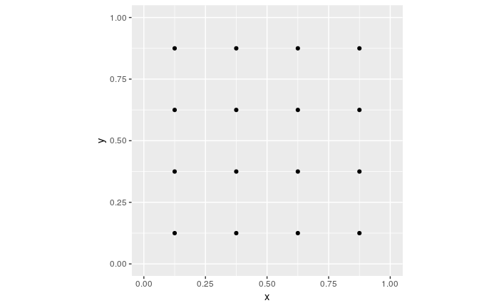

```r
cells_per_row <- 4
gridsize <- 1/cells_per_row
anchor_offset <- 1 / (cells_per_row * 2)
anchor_xs <- seq(anchor_offset, 1 - anchor_offset, length.out = 4) %>%
  rep(each = cells_per_row)
anchor_ys <- seq(anchor_offset, 1 - anchor_offset, length.out = 4) %>%
  rep(cells_per_row)
#We can plot them.
ggplot(data.frame(x = anchor_xs, y = anchor_ys), aes(x, y)) +
  geom_point() +
  coord_cartesian(xlim = c(0,1), ylim = c(0,1)) +
  theme(aspect.ratio = 1)
```

```r
#The center coordinates are supplemented by height and width:
anchor_centers <- cbind(anchor_xs, anchor_ys)
anchor_height_width <- matrix(1 / cells_per_row, nrow = 16, ncol = 2)
#Combining centers, heights and widths gives us the first representation.
anchors <- cbind(anchor_centers, anchor_height_width)
anchors
```

```
      anchor_xs anchor_ys
 [1,]     0.125     0.125 0.25 0.25
 [2,]     0.125     0.375 0.25 0.25
 [3,]     0.125     0.625 0.25 0.25
 [4,]     0.125     0.875 0.25 0.25
 [5,]     0.375     0.125 0.25 0.25
 [6,]     0.375     0.375 0.25 0.25
 [7,]     0.375     0.625 0.25 0.25
 [8,]     0.375     0.875 0.25 0.25
 [9,]     0.625     0.125 0.25 0.25
[10,]     0.625     0.375 0.25 0.25
[11,]     0.625     0.625 0.25 0.25
[12,]     0.625     0.875 0.25 0.25
[13,]     0.875     0.125 0.25 0.25
[14,]     0.875     0.375 0.25 0.25
[15,]     0.875     0.625 0.25 0.25
[16,]     0.875     0.875 0.25 0.25
```

```r
#In subsequent manipulations, we will sometimes we need a different representation: the corners (top-left, top-right, bottom-right, bottom-left) of the grid cells.
hw2corners <- function(centers, height_width) {
  cbind(centers - height_width / 2, centers + height_width / 2) %>% unname()
}
# cells are indicated by (xl, yt, xr, yb)
# successive rows first go down in the image, then to the right
anchor_corners <- hw2corners(anchor_centers, anchor_height_width)
anchor_corners
```

```
      [,1] [,2] [,3] [,4]
 [1,] 0.00 0.00 0.25 0.25
 [2,] 0.00 0.25 0.25 0.50
 [3,] 0.00 0.50 0.25 0.75
 [4,] 0.00 0.75 0.25 1.00
 [5,] 0.25 0.00 0.50 0.25
 [6,] 0.25 0.25 0.50 0.50
 [7,] 0.25 0.50 0.50 0.75
 [8,] 0.25 0.75 0.50 1.00
 [9,] 0.50 0.00 0.75 0.25
[10,] 0.50 0.25 0.75 0.50
[11,] 0.50 0.50 0.75 0.75
[12,] 0.50 0.75 0.75 1.00
[13,] 0.75 0.00 1.00 0.25
[14,] 0.75 0.25 1.00 0.50
[15,] 0.75 0.50 1.00 0.75
[16,] 0.75 0.75 1.00 1.00
```

Let’s take our sample image again and plot it, this time including the grid cells. Note that we display the scaled image now - the way the network is going to see it.

```r
example <- imageinfo4ssd[5, ]
name <- (example$name %>% str_split(pattern = ", "))[[1]]
x_left <- (example$xl %>% str_split(pattern = ", "))[[1]]
x_right <- (example$xr %>% str_split(pattern = ", "))[[1]]
y_top <- (example$yt %>% str_split(pattern = ", "))[[1]]
y_bottom <- (example$yb %>% str_split(pattern = ", "))[[1]]
img <- image_read(file.path(img_dir, example$file_name))
img <- image_resize(img, geometry = "224x224!")
img <- image_draw(img)
for (i in 1:example$cnt) {
  rect(x_left[i],
       y_bottom[i],
       x_right[i],
       y_top[i],
       border = "white",
       lwd = 2)
  text(
    x = as.integer(x_right[i]),
    y = as.integer(y_top[i]),
    labels = name[i],
    offset = 0,
    pos = 2,
    cex = 1,
    col = "white"
  )
}
for (i in 1:nrow(anchor_corners)) {
  rect(
    anchor_corners[i, 1] * 224,
    anchor_corners[i, 4] * 224,
    anchor_corners[i, 3] * 224,
    anchor_corners[i, 2] * 224,
    border = "cyan",
    lwd = 1,
    lty = 3
  )
}
dev.off()
```

```r
print(img)
```

| format | width | height | colorspace | matte | filesize | density |
| --- | --- | --- | --- | --- | --- | --- |
| PNG | 224 | 224 | sRGB | TRUE | 0 | 72x72 |

Matching problem To train the network, we need to assign the ground truth boxes to the grid cells/anchor boxes. We do this based on overlap between bounding boxes on the one hand, and anchor boxes on the other. Overlap is computed using Intersection over Union (IoU, =Jaccard Index), as usual.

Assume we’ve already computed the Jaccard index for all ground truth box - grid cell combinations. We then use the following algorithm:

For each ground truth object, find the grid cell it maximally overlaps with.

For each grid cell, find the object it overlaps with most.

In both cases, identify the entity of greatest overlap as well as the amount of overlap.

When criterium (1) applies, it overrides criterium (2).

When criterium (1) applies, set the amount overlap to a constant, high value: 1.99.

Return the combined result, that is, for each grid cell, the object and amount of best (as per the above criteria) overlap.

Here’s the implementation.

```r
# overlaps shape is: number of ground truth objects * number of grid cells
map_to_ground_truth <- function(overlaps) {

  # for each ground truth object, find maximally overlapping cell (crit. 1)
  # measure of overlap, shape: number of ground truth objects
  prior_overlap <- apply(overlaps, 1, max)
  # which cell is this, for each object
  prior_idx <- apply(overlaps, 1, which.max)

  # for each grid cell, what object does it overlap with most (crit. 2)
  # measure of overlap, shape: number of grid cells
  gt_overlap <-  apply(overlaps, 2, max)
  # which object is this, for each cell
  gt_idx <- apply(overlaps, 2, which.max)

  # set all definitely overlapping cells to respective object (crit. 1)
  gt_overlap[prior_idx] <- 1.99

  # now still set all others to best match by crit. 2
  # actually it's other way round, we start from (2) and overwrite with (1)
  for (i in 1:length(prior_idx)) {
    # iterate over all cells "absolutely assigned"
    p <- prior_idx[i] # get respective grid cell
    gt_idx[p] <- i # assign this cell the object number
  }

  # return: for each grid cell, object it overlaps with most + measure of overlap
  list(gt_overlap, gt_idx)

}
```

Now here’s the IoU calculation we need for that. We can’t just use the IoU function from the previous post because this time, we want to compute overlaps with all grid cells simultaneously. It’s easiest to do this using tensors, so we temporarily convert the R matrices to tensors:

```r
# compute IOU
jaccard <- function(bbox, anchor_corners) {
  bbox <- k_constant(bbox)
  anchor_corners <- k_constant(anchor_corners)
  intersection <- intersect(bbox, anchor_corners)
  union <-
    k_expand_dims(box_area(bbox), axis = 2)  + k_expand_dims(box_area(anchor_corners), axis = 1) - intersection
    res <- intersection / union
  res %>% k_eval()
}
# compute intersection for IOU
intersect <- function(box1, box2) {
  box1_a <- box1[, 3:4] %>% k_expand_dims(axis = 2)
  box2_a <- box2[, 3:4] %>% k_expand_dims(axis = 1)
  max_xy <- k_minimum(box1_a, box2_a)

  box1_b <- box1[, 1:2] %>% k_expand_dims(axis = 2)
  box2_b <- box2[, 1:2] %>% k_expand_dims(axis = 1)
  min_xy <- k_maximum(box1_b, box2_b)

  intersection <- k_clip(max_xy - min_xy, min = 0, max = Inf)
  intersection[, , 1] * intersection[, , 2]

}
box_area <- function(box) {
  (box[, 3] - box[, 1]) * (box[, 4] - box[, 2])
}
```

By now you might be wondering - when does all this happen? Interestingly, the example we’re following, fast.ai’s object detection notebook, does all this as part of the loss calculation! In TensorFlow, this is possible in principle (requiring some juggling of tf$cond, tf$while_loop etc., as well as a bit of creativity finding replacements for non-differentiable operations). But, simple facts - like the Keras loss function expecting the same shapes for y_true and y_pred - made it impossible to follow the fast.ai approach. Instead, all matching will take place in the data generator.

Data generator The generator has the familiar structure, known from the predecessor post. Here is the complete code - we’ll talk through the details immediately.

```r
batch_size <- 16
image_size <- target_width # same as height
threshold <- 0.1
class_background <- 21
ssd_generator <-
  function(data,
           target_height,
           target_width,
           shuffle,
           batch_size) {
    i <- 1
    function() {
      if (shuffle) {
        indices <- sample(1:nrow(data), size = batch_size)
      } else {
        if (i + batch_size >= nrow(data))
          i <<- 1
        indices <- c(i:min(i + batch_size - 1, nrow(data)))
        i <<- i + length(indices)
      }

      x <-
        array(0, dim = c(length(indices), target_height, target_width, 3))
      y1 <- array(0, dim = c(length(indices), 16))
      y2 <- array(0, dim = c(length(indices), 16, 4))

      for (j in 1:length(indices)) {
        x[j, , , ] <-
          load_and_preprocess_image(data[[indices[j], "file_name"]], target_height, target_width)

        class_string <- data[indices[j], ]$categories
        xl_string <- data[indices[j], ]$xl
        yt_string <- data[indices[j], ]$yt
        xr_string <- data[indices[j], ]$xr
        yb_string <- data[indices[j], ]$yb

        classes <-  str_split(class_string, pattern = ", ")[[1]]
        xl <-
          str_split(xl_string, pattern = ", ")[[1]] %>% as.double() %>% `/`(image_size)
        yt <-
          str_split(yt_string, pattern = ", ")[[1]] %>% as.double() %>% `/`(image_size)
        xr <-
          str_split(xr_string, pattern = ", ")[[1]] %>% as.double() %>% `/`(image_size)
        yb <-
          str_split(yb_string, pattern = ", ")[[1]] %>% as.double() %>% `/`(image_size)

        # rows are objects, columns are coordinates (xl, yt, xr, yb)
        # anchor_corners are 16 rows with corresponding coordinates
        bbox <- cbind(xl, yt, xr, yb)
        overlaps <- jaccard(bbox, anchor_corners)

        c(gt_overlap, gt_idx) %<-% map_to_ground_truth(overlaps)
        gt_class <- classes[gt_idx]

        pos <- gt_overlap > threshold
        gt_class[gt_overlap < threshold] <- 21

        # columns correspond to objects
        boxes <- rbind(xl, yt, xr, yb)
        # columns correspond to object boxes according to gt_idx
        gt_bbox <- boxes[, gt_idx]
        # set those with non-sufficient overlap to 0
        gt_bbox[, !pos] <- 0
        gt_bbox <- gt_bbox %>% t()

        y1[j, ] <- as.integer(gt_class) - 1
        y2[j, , ] <- gt_bbox

      }
      x <- x %>% imagenet_preprocess_input()
      y1 <- y1 %>% to_categorical(num_classes = class_background)
      list(x, list(y1, y2))
    }
  }
```

Before the generator can trigger any calculations, it needs to first split apart the multiple classes and bounding box coordinates that come in one row of the dataset.

We copy out code chunk-by-chunk from the generator so results can actually be displayed for inspection.

```r
data <- imageinfo4ssd
indices <- 1:8
j <- 5 # this is our image
class_string <- data[indices[j], ]$categories
xl_string <- data[indices[j], ]$xl
yt_string <- data[indices[j], ]$yt
xr_string <- data[indices[j], ]$xr
yb_string <- data[indices[j], ]$yb

classes <-  str_split(class_string, pattern = ", ")[[1]]
xl <- str_split(xl_string, pattern = ", ")[[1]] %>% as.double() %>% `/`(image_size)
yt <- str_split(yt_string, pattern = ", ")[[1]] %>% as.double() %>% `/`(image_size)
xr <- str_split(xr_string, pattern = ", ")[[1]] %>% as.double() %>% `/`(image_size)
yb <- str_split(yb_string, pattern = ", ")[[1]] %>% as.double() %>% `/`(image_size)
#So here are that image’s classes:
classes
```

```
 [1] "16" "16" "16" "16" "16" "16" "1"  "1"  "1"  "1"  "1"  "1"  "1"  "1"  "11" "11" "5"
```

```r
#And its left bounding box coordinates:
xl
```

```
 [1] 0.4687500 0.5267857 0.5580357 0.4553571 0.4419643 0.4910714 0.5758929 0.5803571 0.6294643 0.6160714
[11] 0.6383929 0.6160714 0.6607143 0.6830357 0.6205357 0.6071429 0.2232143
```

```r
#Now we can cbind those vectors together to obtain a object (bbox) where rows are objects, and coordinates are in the columns:
# rows are objects, columns are coordinates (xl, yt, xr, yb)
bbox <- cbind(xl, yt, xr, yb)
bbox
```

```
             xl        yt        xr        yb
 [1,] 0.4687500 0.2767857 0.4776786 0.2991071
 [2,] 0.5267857 0.2455357 0.5401786 0.2678571
 [3,] 0.5580357 0.3169643 0.5714286 0.3348214
 [4,] 0.4553571 0.3169643 0.4687500 0.3348214
 [5,] 0.4419643 0.3794643 0.4642857 0.4062500
 [6,] 0.4910714 0.3258929 0.5044643 0.3482143
 [7,] 0.5758929 0.3883929 0.5848214 0.4017857
 [8,] 0.5803571 0.3794643 0.5892857 0.3883929
 [9,] 0.6294643 0.5000000 0.6383929 0.5133929
[10,] 0.6160714 0.4776786 0.6250000 0.4910714
[11,] 0.6383929 0.4732143 0.6428571 0.4821429
[12,] 0.6160714 0.5267857 0.6250000 0.5401786
[13,] 0.6607143 0.5669643 0.6696429 0.5803571
[14,] 0.6830357 0.5223214 0.6875000 0.5312500
[15,] 0.6205357 0.2098214 0.6383929 0.2276786
[16,] 0.6071429 0.1741071 0.6205357 0.1875000
[17,] 0.2232143 0.1517857 0.8214286 0.7946429
```

So we’re ready to compute these boxes’ overlap with all of the 16 grid cells. Recall that anchor_corners stores the grid cells in an analogous way, the cells being in the rows and the coordinates in the columns.

```r
# anchor_corners are 16 rows with corresponding coordinates
overlaps <- jaccard(bbox, anchor_corners)
#Now that we have the overlaps, we can call the matching logic:
c(gt_overlap, gt_idx) %<-% map_to_ground_truth(overlaps)
gt_overlap
```

```
 [1] 0.005919283 0.015206373 0.015206373 0.002681924 0.058113202 1.990000000 0.162520722 0.025603514
 [9] 1.990000000 1.990000000 1.990000000 0.025603514 0.015942033 0.041604772 0.041604772 0.007183912
```

```r
gt_idx
```

```
 [1] 17 17 17 17 17 17 17 17 16 11 14 17 17 17 17 17
```

Instead of thinking in object numbers, we should think in object classes (the respective numerical codes, that is).

```r
gt_class <- classes[gt_idx]
gt_class
```

```
 [1] "5"  "5"  "5"  "5"  "5"  "5"  "5"  "5"  "11" "1"  "1"  "5"  "5"  "5"  "5"  "5"
```

```r
pos <- gt_overlap > threshold
gt_class[gt_overlap < threshold] <- 21
gt_class
```

[output not shown]

Now, to construct the targets for learning, we need to put the mapping we found into a data structure.

The following gives us a 16x4 matrix of cells and the boxes they are responsible for:

```r
orig_boxes <- rbind(xl, yt, xr, yb)
# columns correspond to object boxes according to gt_idx
gt_bbox <- orig_boxes[, gt_idx]
# set those with non-sufficient overlap to 0
gt_bbox[, !pos] <- 0
gt_bbox <- gt_bbox %>% t()
gt_bbox
```

```
             xl        yt        xr        yb
 [1,] 0.0000000 0.0000000 0.0000000 0.0000000
 [2,] 0.0000000 0.0000000 0.0000000 0.0000000
 [3,] 0.0000000 0.0000000 0.0000000 0.0000000
 [4,] 0.0000000 0.0000000 0.0000000 0.0000000
 [5,] 0.0000000 0.0000000 0.0000000 0.0000000
 [6,] 0.2232143 0.1517857 0.8214286 0.7946429
 [7,] 0.2232143 0.1517857 0.8214286 0.7946429
 [8,] 0.0000000 0.0000000 0.0000000 0.0000000
 [9,] 0.6071429 0.1741071 0.6205357 0.1875000
[10,] 0.6383929 0.4732143 0.6428571 0.4821429
[11,] 0.6830357 0.5223214 0.6875000 0.5312500
[12,] 0.0000000 0.0000000 0.0000000 0.0000000
[13,] 0.0000000 0.0000000 0.0000000 0.0000000
[14,] 0.0000000 0.0000000 0.0000000 0.0000000
[15,] 0.0000000 0.0000000 0.0000000 0.0000000
[16,] 0.0000000 0.0000000 0.0000000 0.0000000
```

Together, gt_bbox and gt_class make up the network’s learning targets.

```r
y1[j, , ] <- as.integer(gt_class) - 1
y2[j, , ] <- gt_bbox
```

To summarize, our target is a list of two outputs:

- the bounding box ground truth of dimensionality number of grid cells times number of box coordinates, and
- the class ground truth of size number of grid cells times number of classes.

We can verify this by asking the generator for a batch of inputs and targets:

```r
dim(y2)
```

```
[1] 16 16  4
```

The model We start from Resnet 50 as a feature extractor. This gives us tensors of size 7x7x2048.

```r
feature_extractor <- application_resnet50(
  include_top = FALSE,
  input_shape = c(224, 224, 3)
)
```

```
Downloading data from https://github.com/fchollet/deep-learning-models/releases/download/v0.2/resnet50_weights_tf_dim_ordering_tf_kernels_notop.h5
```

Then, we append a few conv layers. Three of those layers are “just” there for capacity; the last one though has a additional task: By virtue of strides = 2, it downsamples its input to from 7x7 to 4x4 in the height/width dimensions.

This resolution of 4x4 gives us exactly the grid we need!

```r
input <- feature_extractor$input
common <- feature_extractor$output %>%
  layer_conv_2d(
    filters = 256,
    kernel_size = 3,
    padding = "same",
    activation = "relu",
    name = "head_conv1_1"
  ) %>%
  layer_batch_normalization() %>%
  layer_conv_2d(
    filters = 256,
    kernel_size = 3,
    padding = "same",
    activation = "relu",
    name = "head_conv1_2"
  ) %>%
  layer_batch_normalization() %>%
  layer_conv_2d(
    filters = 256,
    kernel_size = 3,
    padding = "same",
    activation = "relu",
    name = "head_conv1_3"
  ) %>%
  layer_batch_normalization() %>%
  layer_conv_2d(
    filters = 256,
    kernel_size = 3,
    strides = 2,
    padding = "same",
    activation = "relu",
    name = "head_conv2"
  ) %>%
  layer_batch_normalization()
```

Now we can do as we did in that other post, attach one output for the bounding boxes and one for the classes.

Note how we don’t aggregate over the spatial grid though. Instead, we reshape it so the 4x4 grid cells appear sequentially.

Here first is the class output. We have 21 classes (the 20 classes from PASCAL, plus background), and we need to classify each cell. We thus end up with an output of size 16x21.

```r
class_output <-
  layer_conv_2d(
    common,
    filters = 21,
    kernel_size = 3,
    padding = "same",
    name = "class_conv"
  ) %>%
  layer_reshape(target_shape = c(16, 21), name = "class_output")
```

For the bounding box output, we apply a tanh activation so that values lie between -1 and 1. This is because they are used to compute offsets to the grid cell centers.

These computations happen in the layer_lambda. We start from the actual anchor box centers, and move them around by a scaled-down version of the activations. We then convert these to anchor corners - same as we did above with the ground truth anchors, just operating on tensors, this time.

```r
bbox_output <-
  layer_conv_2d(
    common,
    filters = 4,
    kernel_size = 3,
    padding = "same",
    name = "bbox_conv"
  ) %>%
  layer_reshape(target_shape = c(16, 4), name = "bbox_flatten") %>%
  layer_activation("tanh") %>%
  layer_lambda(
    f = function(x) {
      activation_centers <-
        (x[, , 1:2] / 2 * gridsize) + k_constant(anchors[, 1:2])
      activation_height_width <-
        (x[, , 3:4] / 2 + 1) * k_constant(anchors[, 3:4])
      activation_corners <-
        k_concatenate(
          list(
            activation_centers - activation_height_width / 2,
            activation_centers + activation_height_width / 2
          )
        )
     activation_corners
    },
    name = "bbox_output"
  )
```

Now that we have all layers, let’s quickly finish up the model definition:

To the model’s two outputs - a classification output and a regression output - correspond two losses, just as in the basic classification + localization model. Only this time, we have 16 grid cells to take care of.

Class loss uses tf$nn$sigmoid_cross_entropy_with_logits to compute the binary crossentropy between targets and unnormalized network activation, summing over grid cells and dividing by the number of classes.

```r
# shapes are batch_size * 16 * 21
class_loss <- function(y_true, y_pred) {
  class_loss  <-
    tf$nn$sigmoid_cross_entropy_with_logits(labels = y_true, logits = y_pred)
  class_loss <-
    tf$reduce_sum(class_loss) / tf$cast(n_classes + 1, "float32")

  class_loss
}
```

Localization loss is calculated for all boxes where in fact there is an object present in the ground truth. All other activations get masked out.

The loss itself then is just mean absolute error, scaled by a multiplier designed to bring both loss components to similar magnitudes. In practice, it makes sense to experiment a bit here.

```r
# shapes are batch_size * 16 * 4
bbox_loss <- function(y_true, y_pred) {
  # calculate localization loss for all boxes where ground truth was assigned some overlap
  # calculate mask
  pos <- y_true[, , 1] + y_true[, , 3] > 0
  pos <-
    pos %>% k_cast(tf$float32) %>% k_reshape(shape = c(batch_size, 16, 1))
  pos <-
    tf$tile(pos, multiples = k_constant(c(1L, 1L, 4L), dtype = tf$int32))

  diff <- y_pred - y_true
  # mask out irrelevant activations
  diff <- diff %>% tf$multiply(pos)

  loc_loss <- diff %>% tf$abs() %>% tf$reduce_mean()
  loc_loss * 100
}
```

Training Above, we’ve already defined the model but we still need to freeze the feature detector’s weights and compile it.

```r
model %>% freeze_weights()
model %>% unfreeze_weights(from = "head_conv1_1")
#model
model %>% compile(
  loss = list(class_loss, bbox_loss),
  optimizer = "adam",
  metrics = list(
    class_output = custom_metric("class_loss", metric_fn = class_loss),
    bbox_output = custom_metric("bbox_loss", metric_fn = bbox_loss)
  )
)
```

```
Error in py_call_impl(callable, dots$args, dots$keywords) :
  RuntimeError: Evaluation error: object 'tf' not found.
```